# Practical Machine Learning Project - Quantified Self Movement Data Analysis Report

Sudeep Kumar Kushwaha

# Practical Machine Learning Course Project Report

Initial setup.

```r
library(caret)
```

```r
library(ggplot2)
set.seed(88388)
setwd("~/Practical-Machine-Learning")
```

## Data analysis

Read training data and plot some statistics, e.g., frequency of classes (A through E). The task is to predict activity classes from accelerator measurements of participants performing barbell exercises.

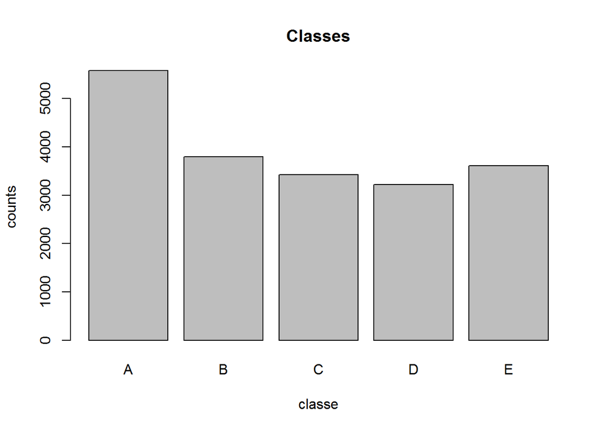

```r
trainRaw=read.table("data/pml-training.csv",header=TRUE,sep=",")
barplot(table(trainRaw$classe),xlab="classe",ylab="counts",main="Classes")
```

```r
dim(trainRaw)
```

```
## [1] 19622   160
```

The training file is rather balanced (more of class A, but not very skewed) and has 19622 instances and 159 variables (the 160th variable is the output to predict, called “classe” that is a factor with 5 levels). The `str` command shows that many columns contain lots of NA’s and that a lot of real-valued data is surrounded by quotes and was thus interpreted incorrectly as factor.

## Data preparation

We now remove all data columns which consist of more than 90% NAs. The data set has now a much lower dimension (93 columns).

```r
train=trainRaw[,colSums(is.na(trainRaw))<(nrow(trainRaw)*0.9)]
dim(train)
```

```
## [1] 19622    93
```

For the remaining columns, we inspect them with `str` to remove those that make less sense (i.e., counters, meta-data, time-related columns).

```r
#names(train)
str(train)
```

```
## 'data.frame':    19622 obs. of  93 variables:
##  $ X                      : int  1 2 3 4 5 6 7 8 9 10 ...
##  $ user_name              : Factor w/ 6 levels "adelmo","carlitos",..: 2 2 2 2 2 2 2 2 2 2 ...
##  $ raw_timestamp_part_1   : int  1323084231 1323084231 1323084231 1323084232 1323084232 1323084232 1323084232 1323084232 1323084232 1323084232 ...
##  $ raw_timestamp_part_2   : int  788290 808298 820366 120339 196328 304277 368296 440390 484323 484434 ...
##  $ cvtd_timestamp         : Factor w/ 20 levels "02/12/2011 13:32",..: 9 9 9 9 9 9 9 9 9 9 ...
##  $ new_window             : Factor w/ 2 levels "no","yes": 1 1 1 1 1 1 1 1 1 1 ...
##  $ num_window             : int  11 11 11 12 12 12 12 12 12 12 ...
##  $ roll_belt              : num  1.41 1.41 1.42 1.48 1.48 1.45 1.42 1.42 1.43 1.45 ...
##  $ pitch_belt             : num  8.07 8.07 8.07 8.05 8.07 8.06 8.09 8.13 8.16 8.17 ...
##  $ yaw_belt               : num  -94.4 -94.4 -94.4 -94.4 -94.4 -94.4 -94.4 -94.4 -94.4 -94.4 ...
##  $ total_accel_belt       : int  3 3 3 3 3 3 3 3 3 3 ...
##  $ kurtosis_roll_belt     : Factor w/ 397 levels "","-0.016850",..: 1 1 1 1 1 1 1 1 1 1 ...
##  $ kurtosis_picth_belt    : Factor w/ 317 levels "","-0.021887",..: 1 1 1 1 1 1 1 1 1 1 ...
##  $ kurtosis_yaw_belt      : Factor w/ 2 levels "","#DIV/0!": 1 1 1 1 1 1 1 1 1 1 ...
```

[output cut: 79 more lines]

```r
#remove columns
train=subset(train, select=-c(X,user_name,raw_timestamp_part_1,raw_timestamp_part_2,cvtd_timestamp,new_window,num_window, kurtosis_yaw_belt,skewness_yaw_belt,max_yaw_belt,min_yaw_belt,amplitude_yaw_belt,kurtosis_yaw_dumbbell,skewness_yaw_dumbbell,amplitude_yaw_dumbbell,amplitude_yaw_dumbbell,skewness_yaw_forearm,amplitude_yaw_forearm,min_yaw_forearm,max_yaw_forearm,skewness_pitch_forearm,skewness_roll_forearm,kurtosis_yaw_forearm,kurtosis_picth_forearm,kurtosis_roll_forearm,max_yaw_dumbbell,min_yaw_dumbbell ))
dim(train)
```

```
## [1] 19622    67
```

```r
#summary(train)
```

We are now down to 67 columns. Inspect again and make sure that all columns are in the right format, otherwise cast them.

```r
train$kurtosis_roll_belt=as.numeric(train$kurtosis_roll_belt)
train$kurtosis_picth_belt=as.numeric(train$kurtosis_picth_belt)
train$skewness_roll_belt=as.numeric(train$skewness_roll_belt)
train$skewness_roll_belt.1=as.numeric(train$skewness_roll_belt.1)
train$kurtosis_roll_arm=as.numeric(train$kurtosis_roll_arm)
train$kurtosis_picth_arm=as.numeric(train$kurtosis_picth_arm)
train$kurtosis_yaw_arm=as.numeric(train$kurtosis_yaw_arm)
train$skewness_roll_arm=as.numeric(train$skewness_roll_arm)
train$skewness_pitch_arm=as.numeric(train$skewness_pitch_arm)
train$skewness_yaw_arm=as.numeric(train$skewness_yaw_arm)
train$kurtosis_roll_dumbbell=as.numeric(train$kurtosis_roll_dumbbell)
train$kurtosis_picth_dumbbell=as.numeric(train$kurtosis_picth_dumbbell)
train$skewness_roll_dumbbell=as.numeric(train$skewness_roll_dumbbell)
train$skewness_pitch_dumbbell=as.numeric(train$skewness_pitch_dumbbell)
```

Now the train data is in the right format, and lets train models.

## Train models on selected data and evaluate on held-out set

We now split the data into parts, and for initial inspection train models only on a random sample of 1000 train and 1000 dev instances to select which method to take. We use Naive Bayes (NB) as baseline method. Since the measurements are clearly not independent, we expect it to work badly. We expect random forests to work well, and compare them to support vector machines (SVM) with a linear and polynomial kernel.

```r
inTrain <- createDataPartition(train$classe, p=0.7,list=FALSE) #same as [[1]] instead of list=FALSE
length(inTrain)
```

```
## [1] 13737
```

```r
inTrain=sample(inTrain,size=1000,replace=FALSE) #subset for testing
training <- train[inTrain,]
testing <- train[-inTrain,]
testing=testing[sample(nrow(testing), 1000),] #random rows
# we try several models for fun
model=train(classe~.,data=training,method="rf")
#model=train(classe~.,data=training,method="nb")
#model=train(classe~.,data=training,method="svmLinear")
#model=train(classe~.,data=training,method="svmPoly")
model
```

```
## Random Forest
##
## 1000 samples
##   66 predictor
##    5 classes: 'A', 'B', 'C', 'D', 'E'
##
## No pre-processing
## Resampling: Bootstrapped (25 reps)
## Summary of sample sizes: 1000, 1000, 1000, 1000, 1000, 1000, ...
## Resampling results across tuning parameters:
##
##   mtry  Accuracy   Kappa
##    2    0.8446468  0.8029903
##   34    0.8722471  0.8381765
##   66    0.8529412  0.8138621
##
## Accuracy was used to select the optimal model using  the largest value.
## The final value used for the model was mtry = 34.
```

```r
predictions=predict(model,newdata=testing)
accuracy=sum(predictions == testing$classe)/length(testing$classe) #or:
confusionMatrix(predictions,testing$classe)
```

```
## Confusion Matrix and Statistics
##
##           Reference
## Prediction   A   B   C   D   E
##          A 249   8   0   3   0
##          B  13 170   7   1   6
##          C   6   9 176  12   7
##          D   4   3   4 138   3
##          E   3   0   1   2 175
##
## Overall Statistics
##
##                Accuracy : 0.908
##                  95% CI : (0.8884, 0.9252)
##     No Information Rate : 0.275
##     P-Value [Acc > NIR] : < 2.2e-16
##
##                   Kappa : 0.884
##  Mcnemar's Test P-Value : 0.003377
##
## Statistics by Class:
##
##                      Class: A Class: B Class: C Class: D Class: E
## Sensitivity            0.9055   0.8947   0.9362   0.8846   0.9162
## Specificity            0.9848   0.9667   0.9581   0.9834   0.9926
## Pos Pred Value         0.9577   0.8629   0.8381   0.9079   0.9669
## Neg Pred Value         0.9649   0.9751   0.9848   0.9788   0.9805
## Prevalence             0.2750   0.1900   0.1880   0.1560   0.1910
## Detection Rate         0.2490   0.1700   0.1760   0.1380   0.1750
## Detection Prevalence   0.2600   0.1970   0.2100   0.1520   0.1810
## Balanced Accuracy      0.9451   0.9307   0.9471   0.9340   0.9544
```

In fact, the worst model is naive Bayes (NB). The best model is – as expected – random forest. More specifically, on the 1000 data sample, the accuracies we get are:

- NB accuracy: 60%,
- RF accuracy: 90.8%
- svmLinear: 69.7%
- svmPoly: 80.1%

## Feature selection

We now want to find the top-20 features of the RF model and train on the whole data set partition.

```r
varImp(model)
```

```
## rf variable importance
##
##   only 20 most important variables shown (out of 66)
##
##                      Overall
## roll_belt             100.00
## pitch_forearm          81.50
## yaw_belt               52.10
## magnet_dumbbell_y      44.82
## magnet_dumbbell_z      41.00
## roll_forearm           32.45
## pitch_belt             28.08
## roll_dumbbell          25.44
## accel_forearm_x        23.03
## accel_dumbbell_y       21.37
## magnet_dumbbell_x      20.57
## magnet_belt_z          18.31
## total_accel_dumbbell   16.38
## magnet_forearm_z       15.50
## magnet_belt_y          15.43
## gyros_belt_z           14.55
## accel_belt_z           13.49
## accel_dumbbell_z       13.26
## magnet_belt_x          13.04
## accel_dumbbell_x       12.60
```

Lets plot some of these features to get a feeling how well they distinguish the classes.

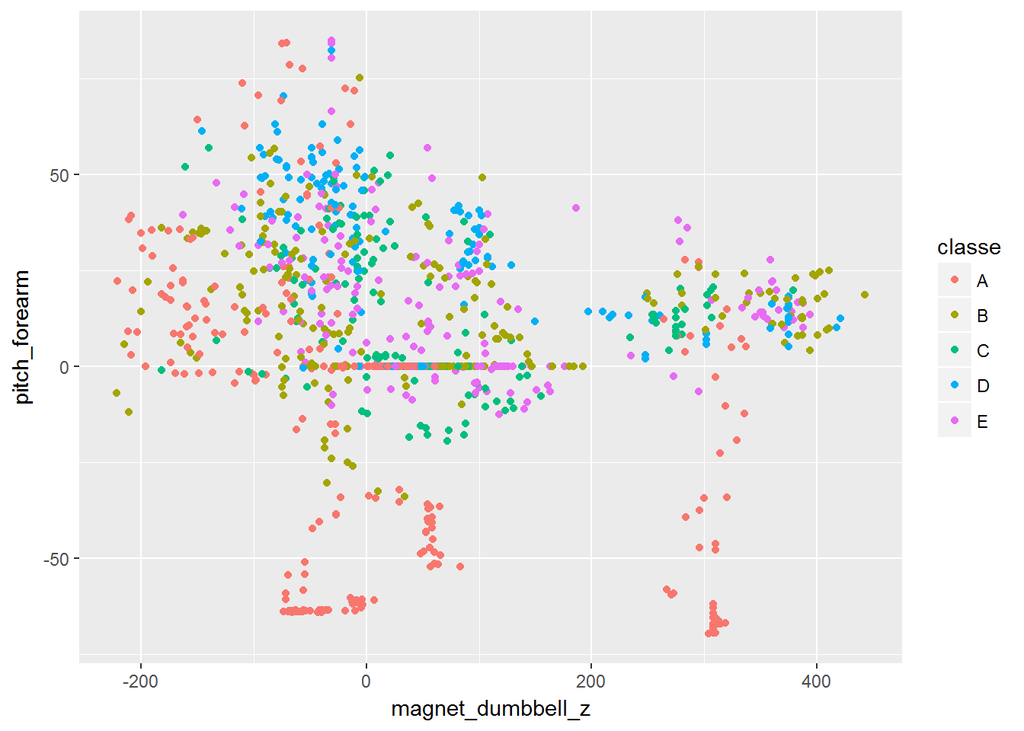

```r
qplot(magnet_dumbbell_z,pitch_forearm,data=training,color=classe)
```

```
inTrain <- createDataPartition(train$classe, p=0.7,list=FALSE) #same as [[1]] instead of list=FALSE
length(inTrain)
training <- train[inTrain,]
testing <- train[-inTrain,]
training=subset(training,select=c(roll_belt,pitch_forearm,magnet_dumbbell_z,magnet_dumbbell_y,yaw_belt,pitch_belt,roll_forearm,magnet_dumbbell_x,roll_dumbbell,magnet_belt_z,accel_forearm_x,accel_dumbbell_y,gyros_dumbbell_y,roll_arm,magnet_belt_x,accel_belt_z,magnet_belt_y,accel_dumbbell_z,magnet_forearm_x ,magnet_forearm_x,total_accel_dumbbell,classe))
testing=subset(testing,select=c(roll_belt,pitch_forearm,magnet_dumbbell_z,magnet_dumbbell_y,yaw_belt,pitch_belt,roll_forearm,magnet_dumbbell_x,roll_dumbbell,magnet_belt_z,accel_forearm_x,accel_dumbbell_y,gyros_dumbbell_y,roll_arm,magnet_belt_x,accel_belt_z,magnet_belt_y,accel_dumbbell_z,magnet_forearm_x ,magnet_forearm_x,total_accel_dumbbell,classe))
dim(training)
```

So far we have trained models on only a subset of the data. To get an estimate of the out-of-sample error we train a random forest model on the whole training data using cross-validation.

```
fitControl <- trainControl(## 10-fold CV
                           method = "repeatedcv",
                           number = 10,
                           repeats = 10)
model=train(classe~.,data=training,method="rf",trControl=fitControl)
```

## Final model

```
model=train(classe~.,data=training,method="rf")
predictions=predict(model,newdata=testing)
accuracy=sum(predictions == testing$classe)/length(testing$classe) #or:
accuracy
confusionMatrix(predictions,testing$classe)
```

Now we run it on the real test data and write the predictions to the files. Submitting the test run on the website shows that we actually got an accuracy of 100% (with just 20 features). Thus, our estimate carried nicely over. Yeah!

```
testRaw=read.table("data/pml-testing.csv",header=TRUE,sep=",")
testing=subset(testRaw,select=c(roll_belt,pitch_forearm,magnet_dumbbell_z,magnet_dumbbell_y,yaw_belt,pitch_belt,roll_forearm,magnet_dumbbell_x,roll_dumbbell,magnet_belt_z,accel_forearm_x,accel_dumbbell_y,gyros_dumbbell_y,roll_arm,magnet_belt_x,accel_belt_z,magnet_belt_y,accel_dumbbell_z,magnet_forearm_x ,magnet_forearm_x,total_accel_dumbbell))
dim(testing)
predictionsTest=predict(model,newdata=testing)
length(predictionsTest)

pml_write_files = function(x){
  n = length(x)
  for(i in 1:n){
    filename = paste0("problem_id_",i,".txt")
    write.table(x[i],file=filename,quote=FALSE,row.names=FALSE,col.names=FALSE)
  }
}
pml_write_files(predictionsTest)
```

### References

[1] http://groupware.les.inf.puc-rio.br/har

[2] Ugulino, W.; Cardador, D.; Vega, K.; Velloso, E.; Milidiu, R.; Fuks, H. Wearable Computing: Accelerometers’ Data Classification of Body Postures and Movements. Proceedings of 21st Brazilian Symposium on Artificial Intelligence. Advances in Artificial Intelligence - SBIA 2012. In: Lecture Notes in Computer Science. , pp. 52-61. Curitiba, PR: Springer Berlin / Heidelberg, 2012.